# ICCB Species distribution modelling and validation

- Show All Code
- Hide All Code
- View Source

Author

Scott Forrest and Charlotte Patterson

Published

April 16, 2025

Abstract

In this script we are fitting species distribution models to the data of koalas (Phascolarctos cinereus) in the South-East Queensland (SEQ) region under current environmental conditions, which we will predict into future environmental conditions.

We wrote this script drawing on some of the following resources:

-Ecocommons Notebooks https://www.ecocommons.org.au/notebooks/

-Damaris Zurell’s SDM Intro https://damariszurell.github.io/SDM-Intro/

https://damariszurell.github.io/EEC-MGC/b4_SDM_eval.html

## Import packages

```r
library(dplyr)
library(purrr)
library(ggplot2)
library(terra)
library(sf)
library(predicts)
library(blockCV)
library(ecospat)
library(usdm)
library(randomForest)
library(precrec)
library(corrplot)
# Install the mecofun package, used in the materials at https://damariszurell.github.io/SDM-Intro/
library(devtools)
devtools::install_git("https://gitup.uni-potsdam.de/macroecology/mecofun.git")
# Load the mecofun package
library(mecofun)
```

## Load koala presences and background points

They are loaded as spatvectors, but we also want them as dataframes for model input requirements.

```r
koala_occ <- vect("Data/Biological_records/SEQ_koala_occurrences.shp")
background <- vect("Data/Biological_records/background_points_2.5k_random.shp")

# Make a dataframe of just x, y and presence
koala_occ_df <- koala_occ %>%
  as.data.frame(geom = "XY") %>%
  dplyr::select(x,y) %>%
  mutate(Presence = 1)

head(koala_occ_df)
```

|  | x | y | Presence |
| --- | --- | --- | --- |
| 1 | 1868673 | -3265806 | 1 |
| 2 | 1851054 | -3232106 | 1 |
| 3 | 1846917 | -3231913 | 1 |
| 4 | 1874167 | -3262365 | 1 |
| 5 | 1857487 | -3259935 | 1 |
| 6 | 1874262 | -3262395 | 1 |

```r
background_df <- background %>%
  as.data.frame(geom = "XY") %>%
  dplyr::select(x,y) %>%
  mutate(Presence = 0)

head(background_df)
```

|  | x | y | Presence |
| --- | --- | --- | --- |
| 1 | 1854692 | -3111330 | 0 |
| 2 | 1859816 | -3111330 | 0 |
| 3 | 1864940 | -3111330 | 0 |
| 4 | 1870064 | -3111330 | 0 |
| 5 | 1875188 | -3111330 | 0 |
| 6 | 1880312 | -3111330 | 0 |

```r
# Combine to one
pr_bg <- rbind(koala_occ_df, background_df)
```

## Load environmental covariates

Loading current covariate rasters. We formatted these rasters in the same way as the Koala data, so that they are all in the same projection and extent. We did this in the script: ‘ICCB_Environmental_data.qmd’

```r
covs_current <- rast("Data/Environmental_variables/current_bioclim.tif")


# Define the BIOCLIM names for the raster layers
layer_names <- c(
  "BIO1_Annual_Mean_Temp",
  "BIO2_Mean_Diurnal_Temp_Range",
  "BIO3_Isothermality",
  "BIO4_Temperature_Seasonality",
  "BIO5_Max_Temp_Warmest_Month",
  "BIO6_Min_Temp_Coldest_Month",
  "BIO7_Temperature_Annual_Range",
  "BIO8_Mean_Temp_Wettest_Quarter",
  "BIO9_Mean_Temp_Driest_Quarter",
  "BIO10_Mean_Temp_Warmest_Quarter",
  "BIO11_Mean_Temp_Coldest_Quarter",
  "BIO12_Annual_Precipitation",
  "BIO13_Precip_Wettest_Month",
  "BIO14_Precip_Driest_Month",
  "BIO15_Precip_Seasonality",
  "BIO16_Precip_Wettest_Quarter",
  "BIO17_Precip_Driest_Quarter",
  "BIO18_Precip_Warmest_Quarter",
  "BIO19_Precip_Coldest_Quarter")

names(covs_current) <- layer_names
```

## Covariate selection

### Option 1. Narrow down potential covariates based on ecological knowledge

For this example, we had advice from CSIRO scientists who conducted an expert elicitation to gather a set of potential covariates that are likely to be important for koalas. We use this knowledge to filter out the key bioclim variables.

We select the following: Bio5 : Max temp of the warmest month (mainly for the northern populations) Bio6 : Min temp of the coldest month (mainly for southern populations, which essentially excludes alpine regions) Bio12 : Annual Precipitation Bio15 : Precipitation seasonality (coefficient of variation)

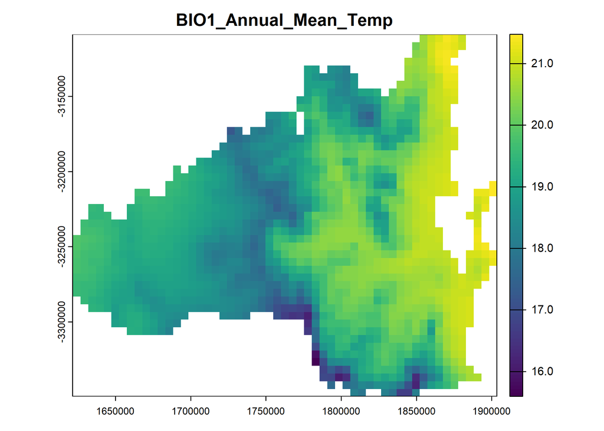

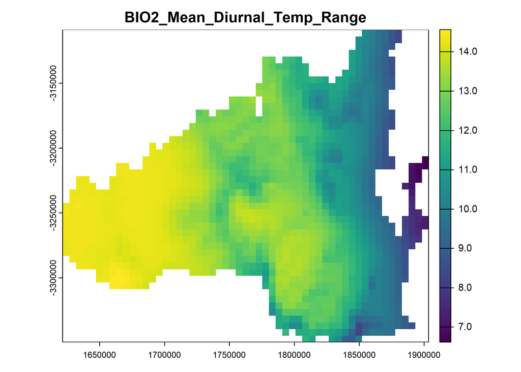

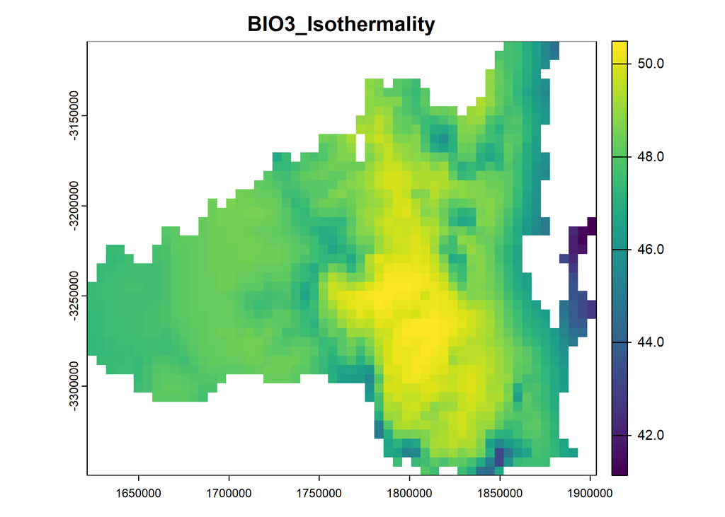

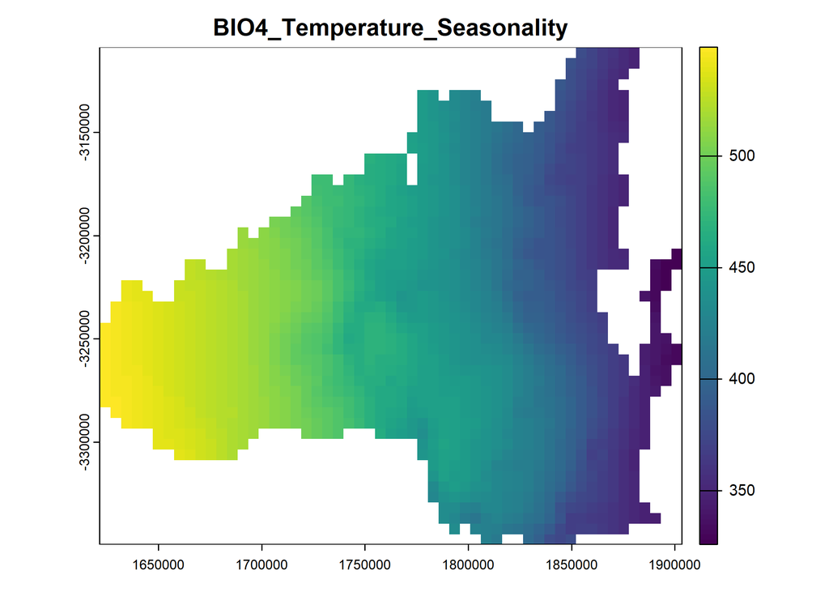

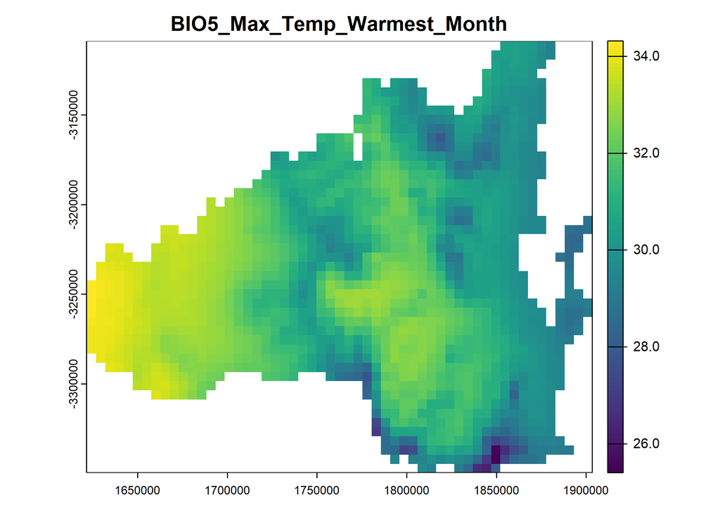

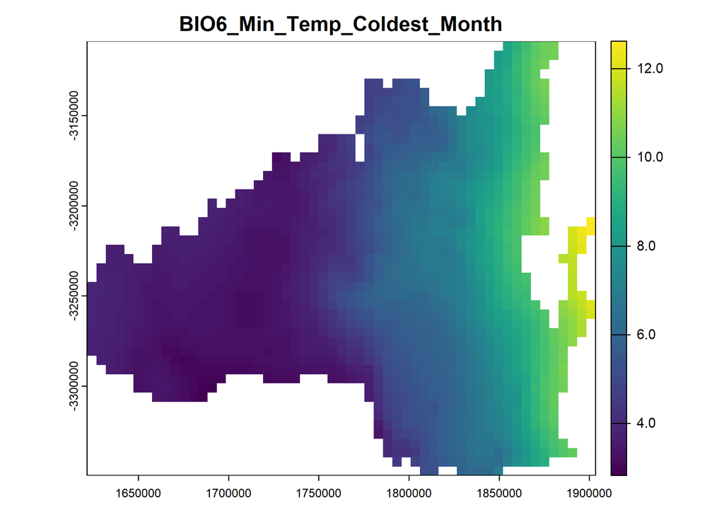

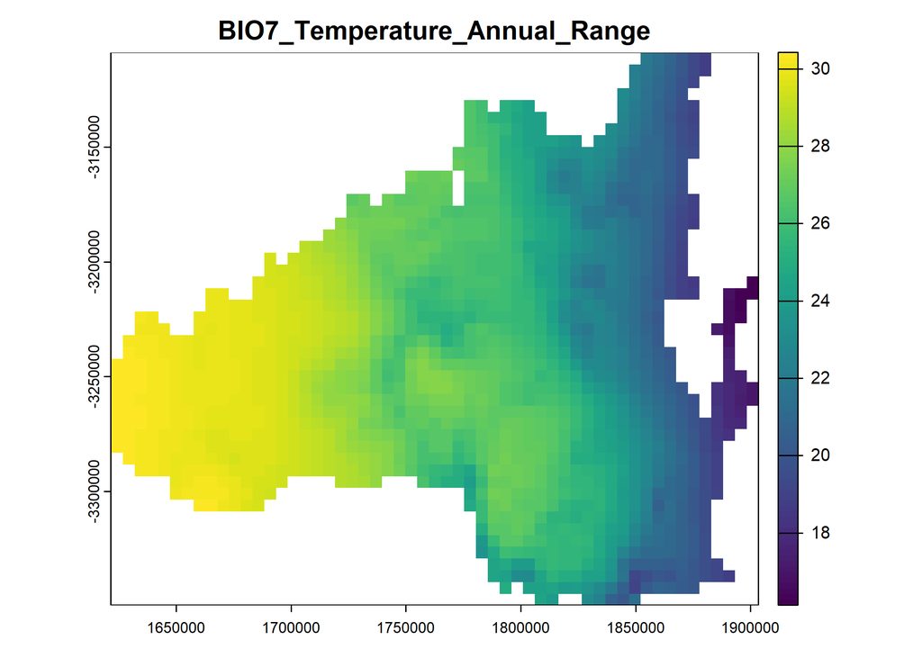

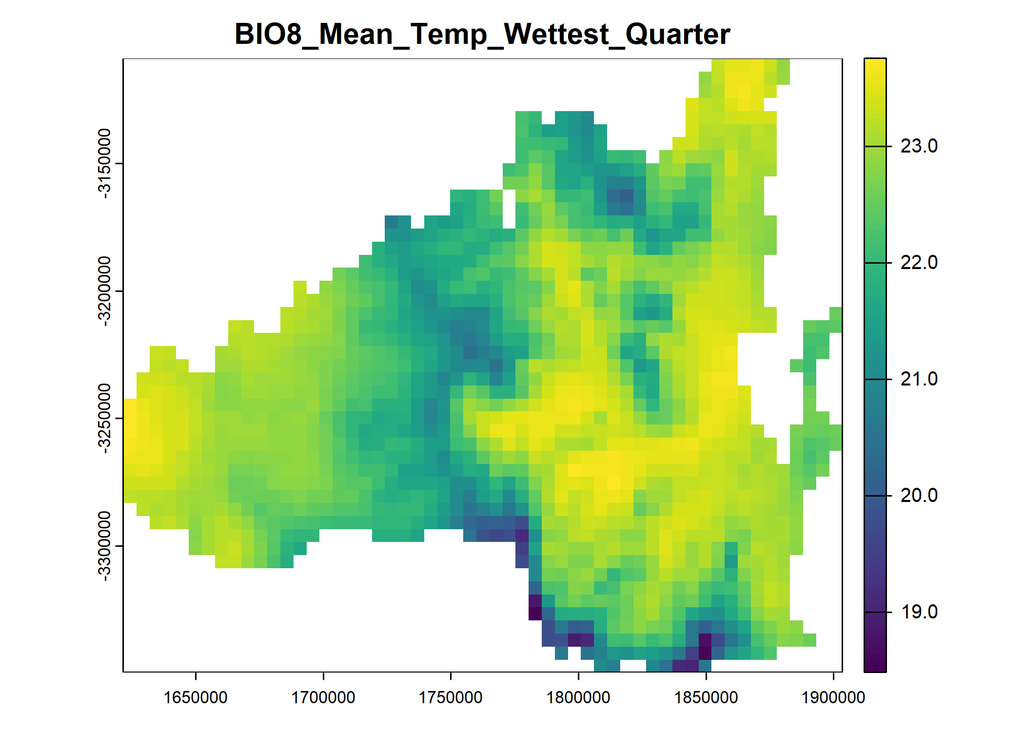

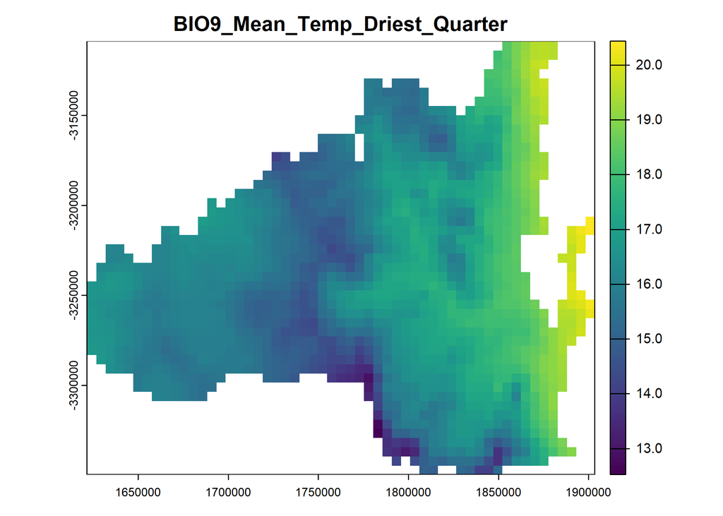

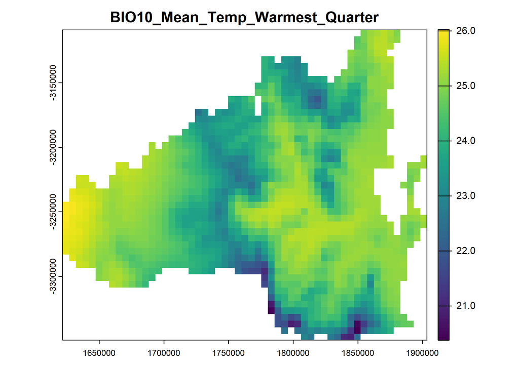

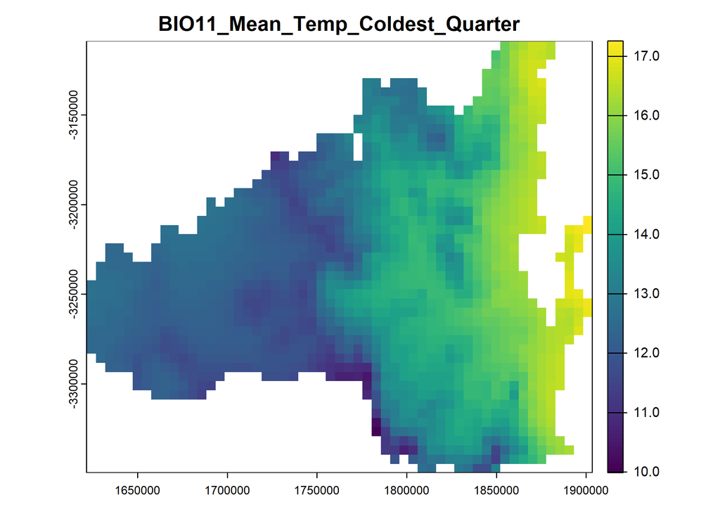

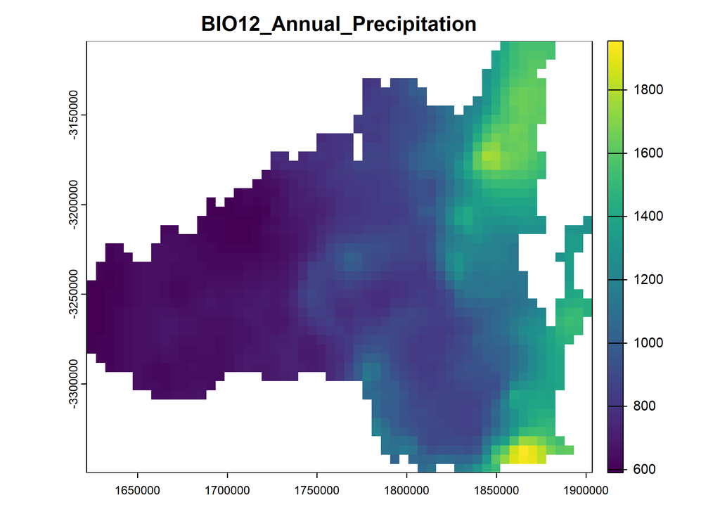

[7 more figures not shown]

```r
for(i in 1:nlyr(covs_current)) {
  terra::plot(covs_current[[i]], main = names(covs_current)[[i]])
}
```

## Show the four from expert elicitation the layers

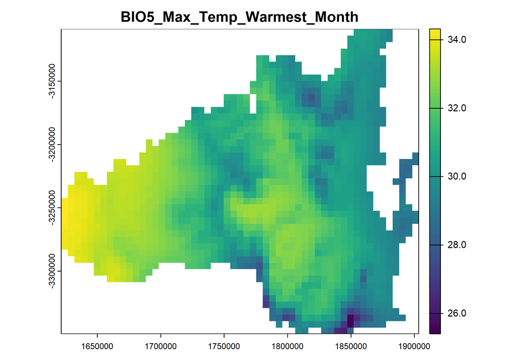

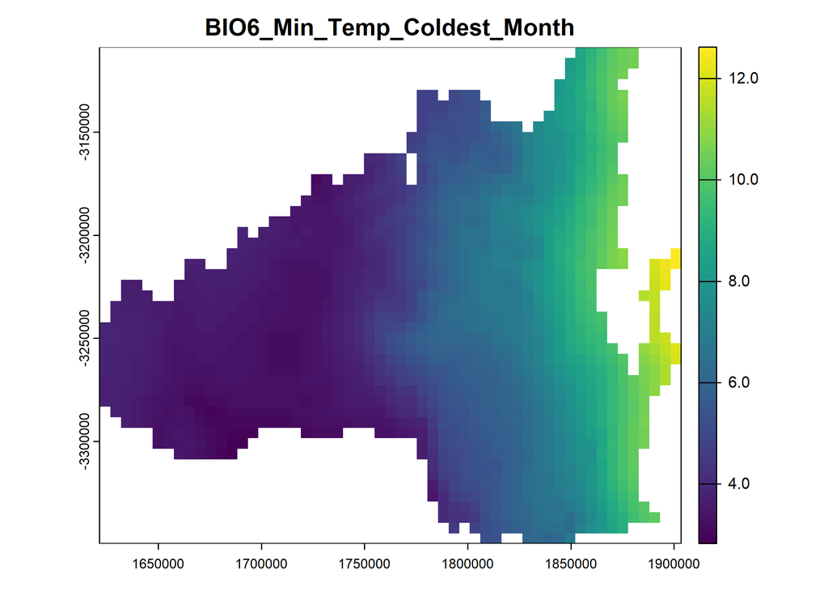

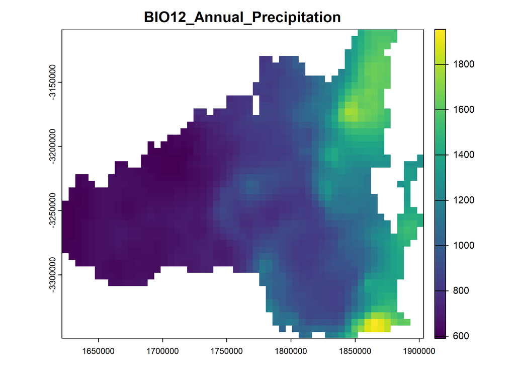

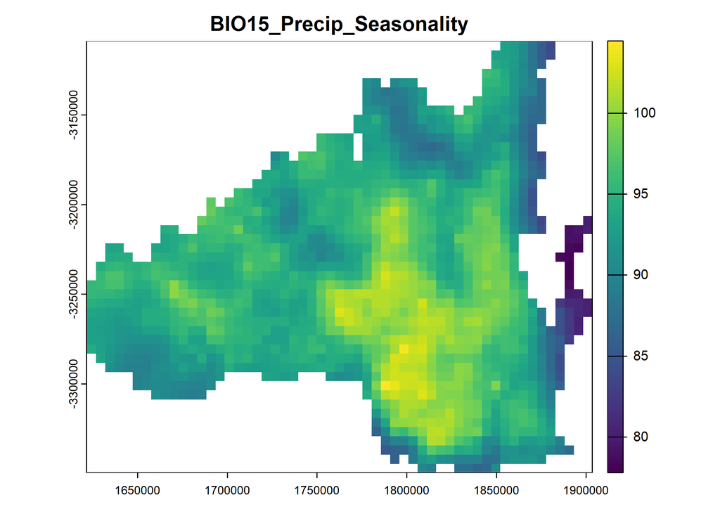

```r
covs_current_expert <- subset(covs_current, names(covs_current) %in% c("BIO5_Max_Temp_Warmest_Month",
                                                                       "BIO6_Min_Temp_Coldest_Month",
                                                                       "BIO12_Annual_Precipitation",
                                                                       "BIO15_Precip_Seasonality"))

for(i in 1:nlyr(covs_current_expert)) {
  terra::plot(covs_current_expert[[i]], main = names(covs_current_expert)[[i]])
}
```

## Extract environmental covariate values from presence and background locations (training locations)

```r
train_PB_covs <- terra::extract(covs_current, pr_bg[,c("x", "y")], xy = T)
train_PB_covs <- cbind(train_PB_covs, pr_bg["Presence"])

# Remove rows where there's values missing from at least one covariate
print(paste0("RECORDS FROM ", nrow(train_PB_covs) - sum(complete.cases(train_PB_covs)), " ROWS IN TRAINING DATA REMOVED DUE TO MISSING COVARIATE VALUES"))
```

```
[1] "RECORDS FROM 68 ROWS IN TRAINING DATA REMOVED DUE TO MISSING COVARIATE VALUES"
```

```r
train_PB_covs <- train_PB_covs[complete.cases(train_PB_covs), ]
train_PB_covs <- dplyr::select(train_PB_covs, -ID)

head(train_PB_covs)
```

|  | BIO1_Annual_Mean_Temp | BIO2_Mean_Diurnal_Temp_Range | BIO3_Isothermality | BIO4_Temperature_Seasonality | BIO5_Max_Temp_Warmest_Month | BIO6_Min_Temp_Coldest_Month | BIO7_Temperature_Annual_Range | BIO8_Mean_Temp_Wettest_Quarter | BIO9_Mean_Temp_Driest_Quarter | BIO10_Mean_Temp_Warmest_Quarter | BIO11_Mean_Temp_Coldest_Quarter | BIO12_Annual_Precipitation | BIO13_Precip_Wettest_Month | BIO14_Precip_Driest_Month | BIO15_Precip_Seasonality | BIO16_Precip_Wettest_Quarter | BIO17_Precip_Driest_Quarter | BIO18_Precip_Warmest_Quarter | BIO19_Precip_Coldest_Quarter | x | y | Presence |
| --- | --- | --- | --- | --- | --- | --- | --- | --- | --- | --- | --- | --- | --- | --- | --- | --- | --- | --- | --- | --- | --- | --- |
| 1 | 20.73219 | 9.515615 | 46.85551 | 367.6388 | 29.73501 | 9.386996 | 20.34801 | 22.98827 | 18.36451 | 24.94183 | 15.92675 | 1238.362 | 327.7901 | 10.800349 | 92.89355 | 606.3058 | 94.95189 | 449.8074 | 189.9305 | 1870064 | -3265048 | 1 |
| 2 | 20.85025 | 10.291359 | 47.88751 | 379.8710 | 30.47122 | 8.940289 | 21.53093 | 23.55152 | 18.09120 | 25.18869 | 15.87509 | 1165.235 | 327.1804 | 8.330686 | 98.80420 | 598.7009 | 77.30684 | 444.0957 | 147.6409 | 1849568 | -3234305 | 1 |
| 3 | 20.61474 | 10.648253 | 48.39870 | 384.8382 | 30.53297 | 8.487451 | 22.04552 | 23.31077 | 17.78633 | 24.99932 | 15.57214 | 1161.138 | 327.4446 | 8.048150 | 99.45329 | 598.9535 | 75.86132 | 445.4260 | 145.7036 | 1844444 | -3234305 | 1 |
| 4 | 21.00405 | 9.129249 | 46.28033 | 363.1416 | 29.72843 | 9.958574 | 19.76986 | 23.01914 | 18.89500 | 25.18043 | 16.27002 | 1222.618 | 311.3793 | 11.913177 | 88.93709 | 583.3614 | 100.51526 | 448.1904 | 200.5528 | 1875188 | -3259924 | 1 |
| 5 | 20.75752 | 10.070734 | 47.49575 | 378.2968 | 30.20078 | 8.959633 | 21.24114 | 23.32381 | 18.13480 | 25.08320 | 15.80299 | 1109.354 | 305.5583 | 8.327950 | 97.22968 | 558.9021 | 77.90620 | 408.9403 | 153.3001 | 1859816 | -3259924 | 1 |
| 6 | 21.00405 | 9.129249 | 46.28033 | 363.1416 | 29.72843 | 9.958574 | 19.76986 | 23.01914 | 18.89500 | 25.18043 | 16.27002 | 1222.618 | 311.3793 | 11.913177 | 88.93709 | 583.3614 | 100.51526 | 448.1904 | 200.5528 | 1875188 | -3259924 | 1 |

## Thin the koala presence points (for tutorial only)

We now thin the presences to reduce the number of points to a manageable size for plotting and modelling. This is not a recommended step for real data, but is done here to make the tutorial run faster and to make the plots clearer.

```r
train_PB_covs_pres <- train_PB_covs %>% filter(Presence == 1)
train_PB_covs_bg <- train_PB_covs %>% filter(Presence == 0)

# Thin the presences for plotting
train_PB_covs_pres_thin <- train_PB_covs_pres[sample(nrow(train_PB_covs_pres), 10000), ]

# Combine back into both presence and background
train_PB_covs_thinned <- rbind(train_PB_covs_pres_thin, train_PB_covs_bg)
```

## Check correlation and multicollinearity of covariates

### Correlation plot

There are several different methods for creating correlation plots.

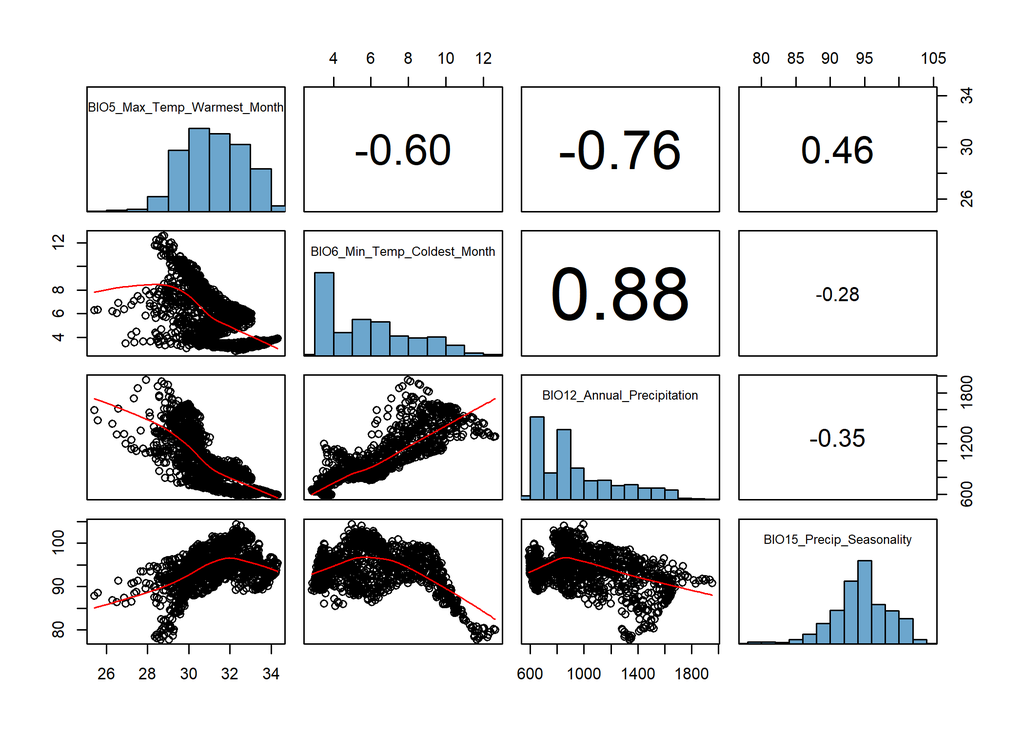

```r
ecospat.cor.plot(covs_current_expert)
```

### Using the corplots package

For a simple and quick plot.

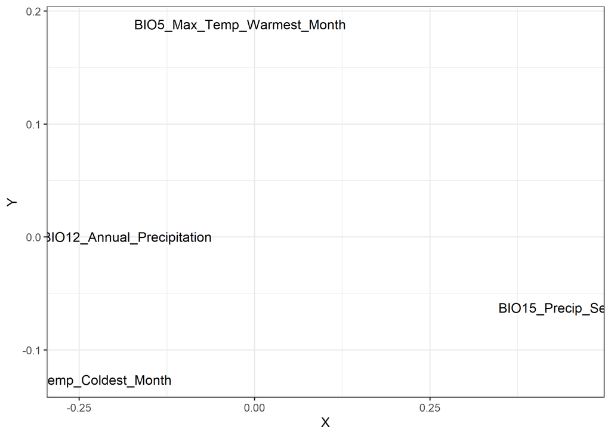

```r
corplots <- ENMTools::raster.cor.plot(covs_current_expert)
corplots$cor.mds.plot
```

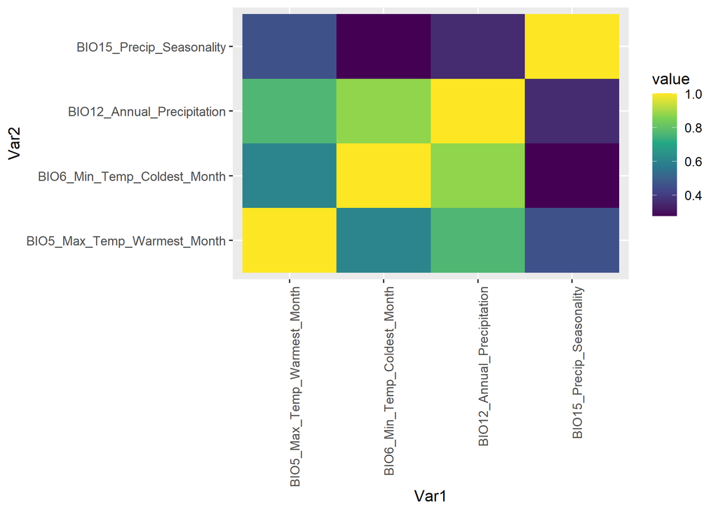

```r
corplots$cor.heatmap
```

Here, we use the `corrplot` package to create a correlation plot of the selected covariates (this is taken from an EcoCommons Australia notebook).

```r
# Select columns by their names
cor_data <- train_PB_covs[, names(train_PB_covs) %in% c("BIO5_Max_Temp_Warmest_Month",
                                                        "BIO6_Min_Temp_Coldest_Month",
                                                        "BIO12_Annual_Precipitation",
                                                        "BIO15_Precip_Seasonality")]

# Check the structure of the numeric data
str(cor_data)
```

```
'data.frame':   87611 obs. of  4 variables:
 $ BIO5_Max_Temp_Warmest_Month: num  29.7 30.5 30.5 29.7 30.2 ...
 $ BIO6_Min_Temp_Coldest_Month: num  9.39 8.94 8.49 9.96 8.96 ...
 $ BIO12_Annual_Precipitation : num  1238 1165 1161 1223 1109 ...
 $ BIO15_Precip_Seasonality   : num  92.9 98.8 99.5 88.9 97.2 ...
```

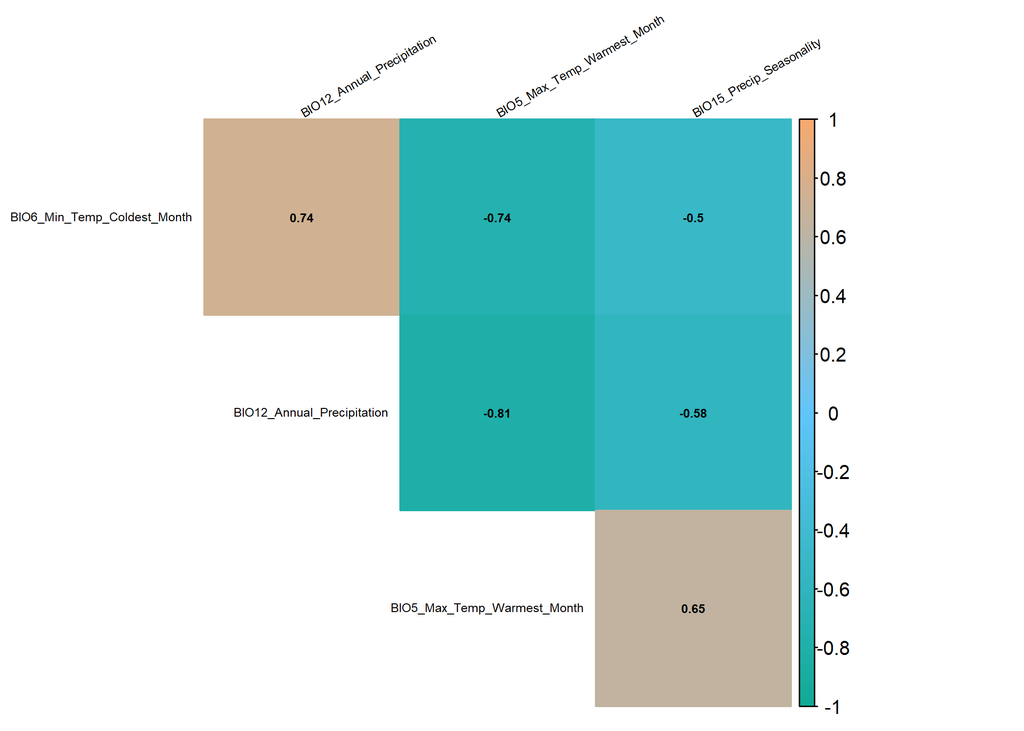

```r
# Calculate the correlation matrix for the numeric columns
cor_matrix <- cor(cor_data, use = "complete.obs", method = "pearson")


corrplot(cor_matrix,
         method = "color",            # Use colored squares for correlation
         type = "upper",              # Show upper triangle only
         order = "hclust",            # Reorder variables hierarchically
         addCoef.col = "black",       # Show correlation coefficients in black
         number.cex = 0.5,            # Reduce the size of correlation labels
         tl.col = "black",            # Text label color
         tl.srt = 30,                 # Rotate labels slightly for readability
         tl.cex = 0.5,                # Reduce text size of variable labels (set smaller valu)
         cl.cex = 0.8,                # Reduce text size of color legend
         diag = FALSE,                # Hide diagonal
         col = colorRampPalette(c("#11aa96", "#61c6fa", "#f6aa70"))(200),
         sig.level = 0.01, insig = "blank")
```

### Variance Inflation Factor (VIF)

If you find corrplot is hard for you to make decisions, we can use Variance Inflation Factor (VIF). VIF is another statistical measure used to detect multicollinearity in a set of explanatory (independent) variables in a regression model.

**Interpretation:**

- VIF = 1: No correlation
- VIF > 1 and <= 5: Moderate correlation; may not require corrective action.
- VIF > 5: Indicates high correlation. Multicollinearity may be problematic, and further investigation is recommended.
- VIF > 10: Strong multicollinearity. The variable is highly collinear with others, and steps should be taken to address this.

```r
# usdm::vif(covs_current_expert) # just VIF for all covariates
usdm::vifstep(covs_current_expert) # Variance Inflation Factor and test for multicollinearity
```

```
No variable from the 4 input variables has collinearity problem.

The linear correlation coefficients ranges between:
min correlation ( BIO15_Precip_Seasonality ~ BIO6_Min_Temp_Coldest_Month ):  -0.2756697
max correlation ( BIO12_Annual_Precipitation ~ BIO6_Min_Temp_Coldest_Month ):  0.8769718

---------- VIFs of the remained variables --------
                    Variables      VIF
1 BIO5_Max_Temp_Warmest_Month 2.751370
2 BIO6_Min_Temp_Coldest_Month 4.528719
3  BIO12_Annual_Precipitation 6.888077
4    BIO15_Precip_Seasonality 1.263385
```

## Exploration of the koala presence and background data

It is good practice to assess where in the environmental space the presence and background points are located. This can help to identify if there are any potential issues with the data, such as a lack of background points in certain areas of environmental space, and should show any patterns in the data that the model should pick up.

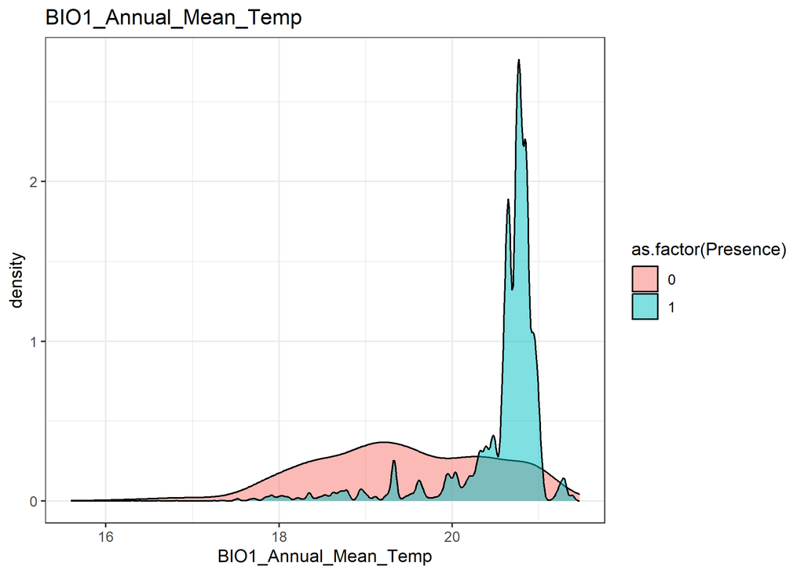

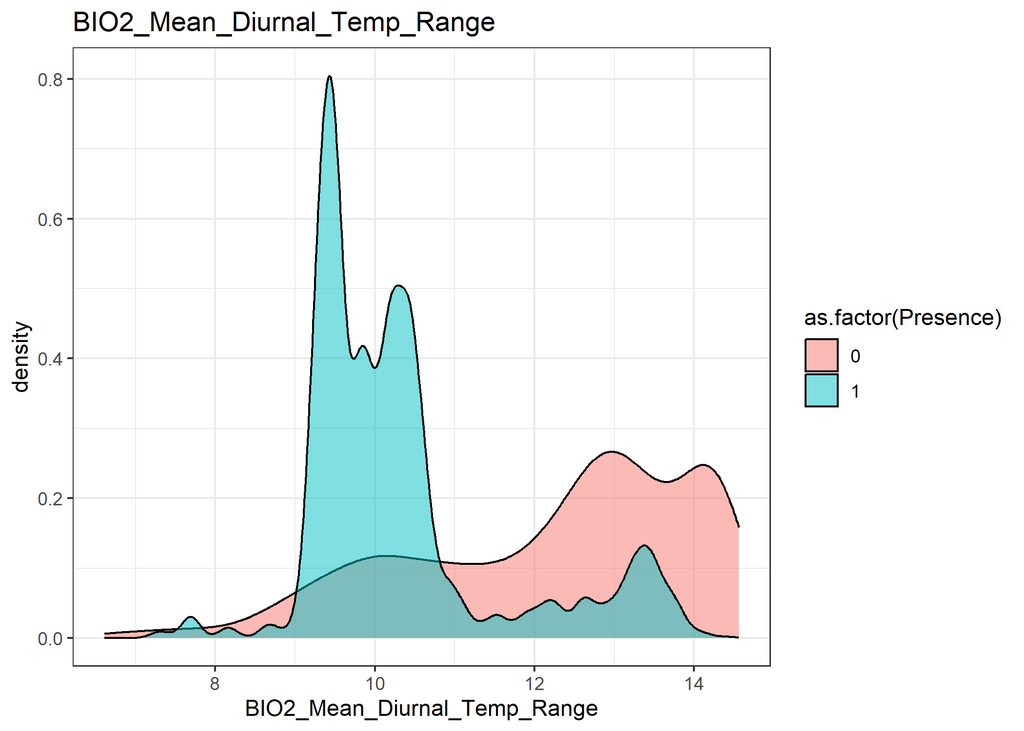

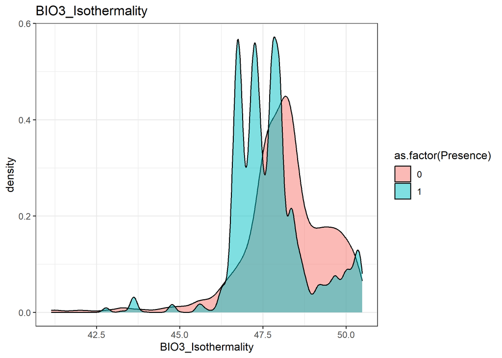

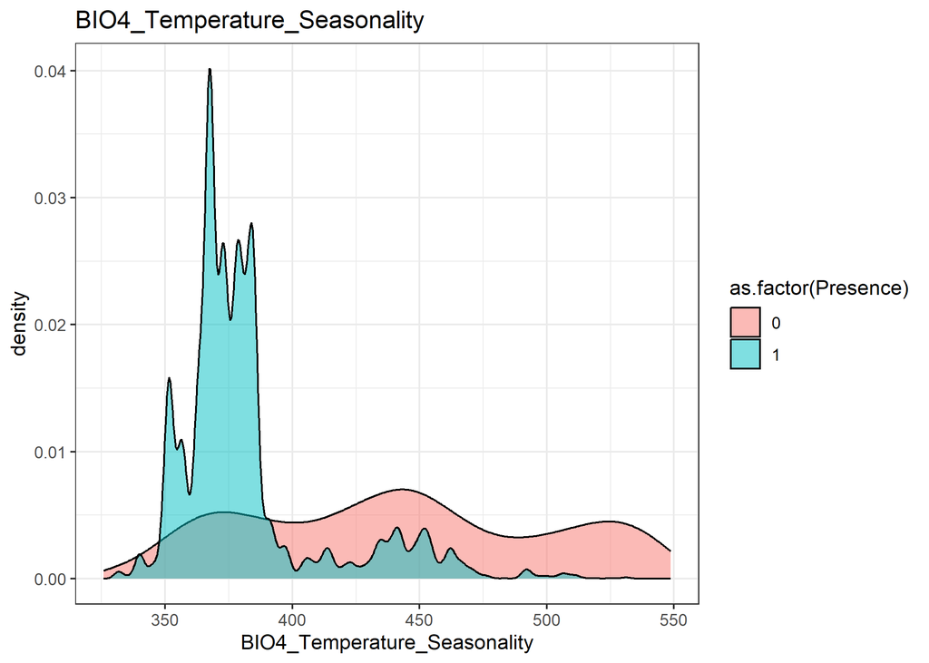

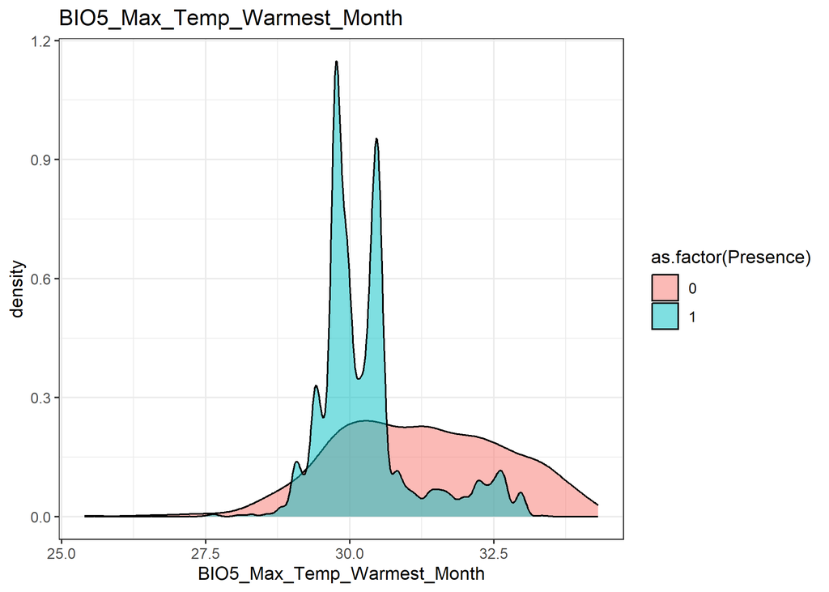

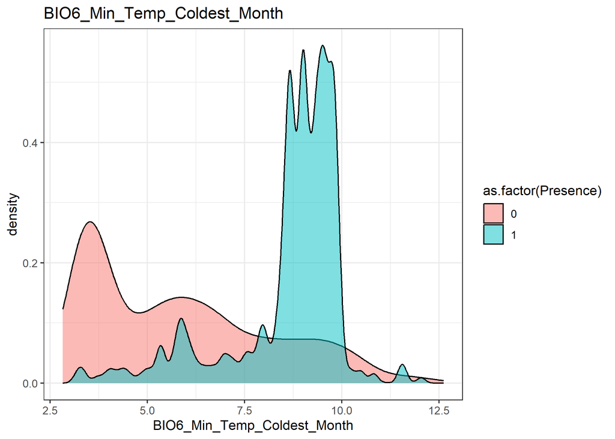

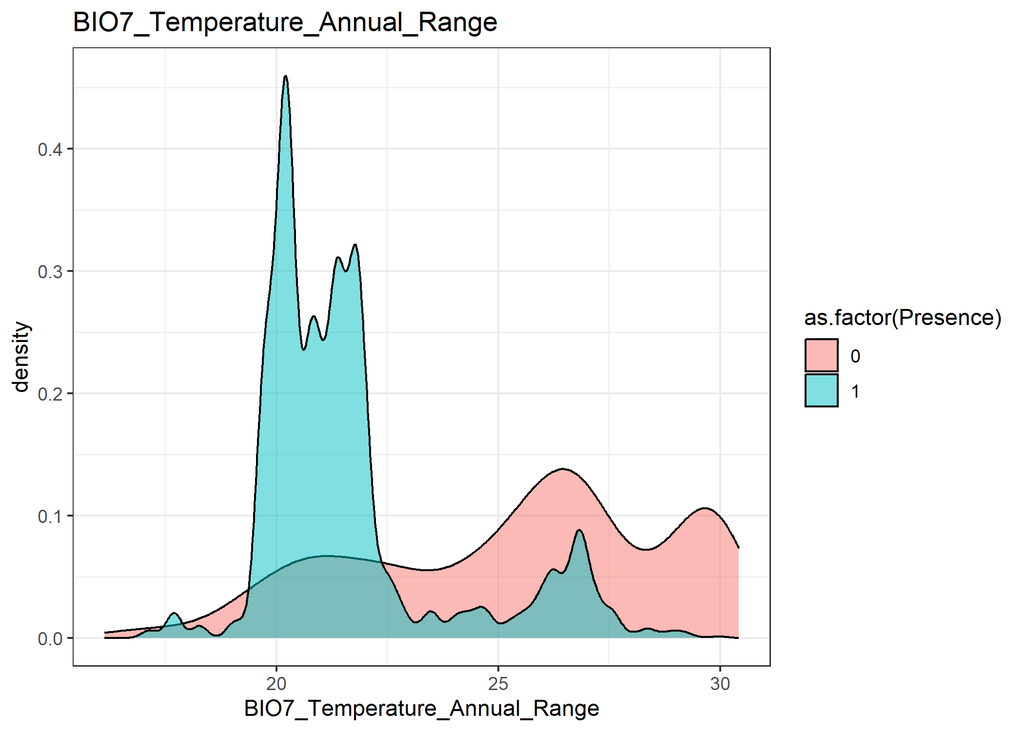

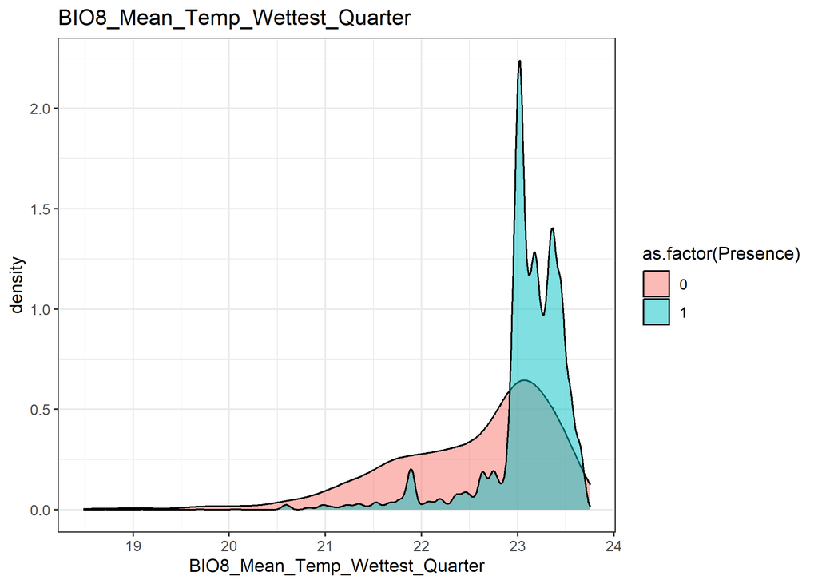

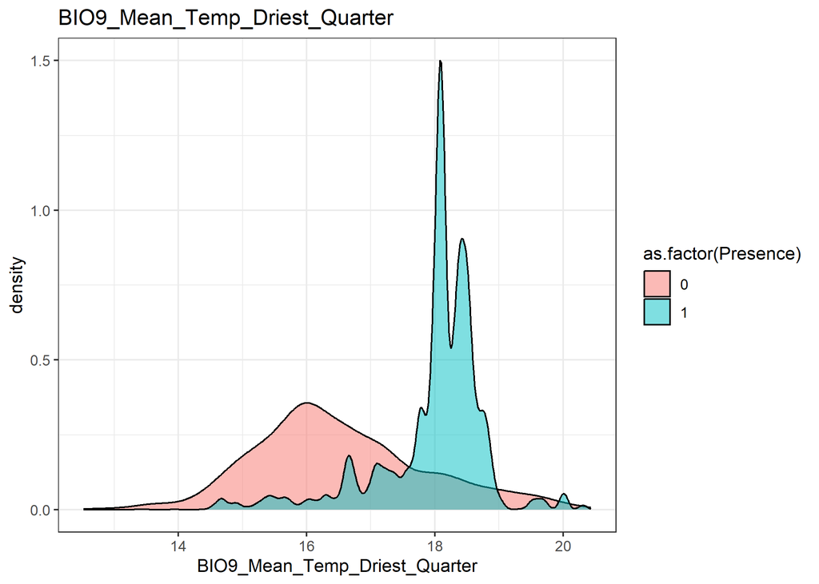

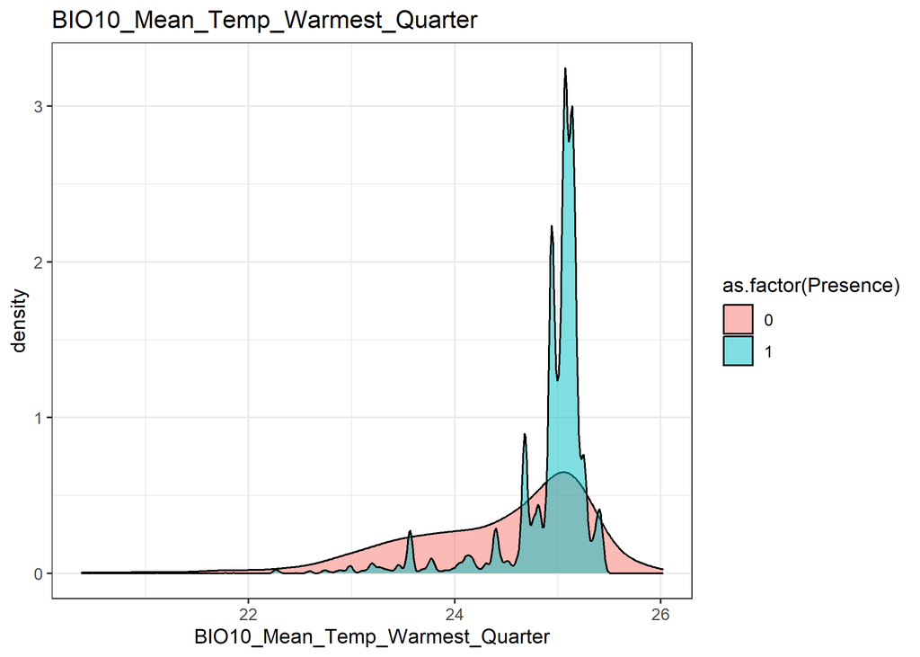

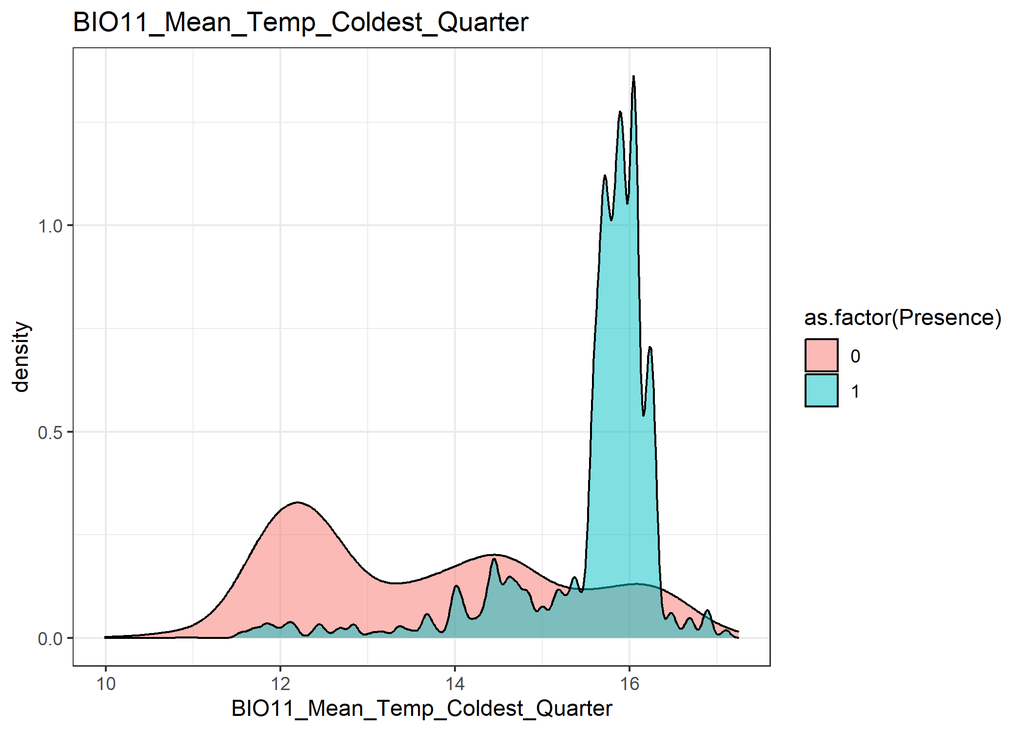

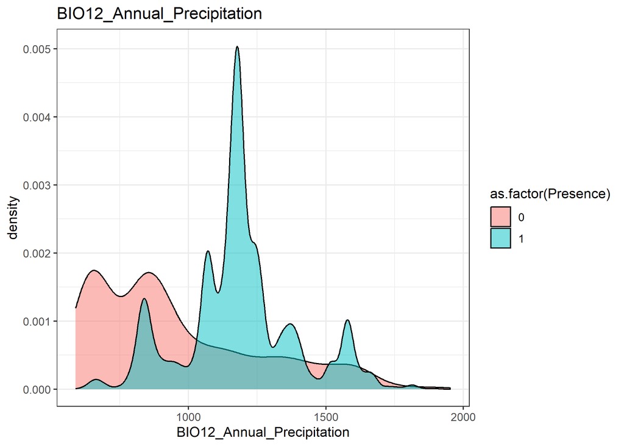

[10 more figures not shown]

```r
# Iterate over all of the variables to create density plots of the background and presence data
for(i in 1:ncol(train_PB_covs_thinned)) {

  print(ggplot() +
          geom_density(data = train_PB_covs_thinned,
                       aes(x = .data[[names(train_PB_covs_thinned)[i]]], fill = as.factor(Presence)),
                       alpha = 0.5) +
    theme_bw() +
    labs(title = names(train_PB_covs_thinned)[i]))

}
```